# HW05 Exploring Relationships Sample Report

your name

# Variables of Interest

| Original Variable | New Variable | Description |
| --- | --- | --- |
| BIO_SEX4 | gender | subject’s gender |
| H4ED2 | education | Highest level of education completed (5 levels) |
| H4DA11 | vigorous_activity | In the past 24 hours, have you participated in vigorous physical activity long enough to work up a sweat, get your heart thumping, or get out of breath? |
| H4LM19 | hrs_worked_week | How many hours a week (do/did) you usually work at this job? |

# Part One : Relationship between categorical variables

## Stress Easily and Partner Shows Love

### Table

```r
demo %>%

  filter(partner_express_love %in% c("agree","neither agree nor disagree","disagree"),
         stress_easily %in% c("agree","neither agree nor disagree","disagree")) %>%
  droplevels() %>%

  tabyl(partner_express_love, stress_easily) %>%   ### tabyl(explanatory, response)
    adorn_totals(c("row")) %>%
    adorn_percentages("row") %>%
    adorn_pct_formatting(digits=0) %>%

  kable() %>%
    kable_styling(bootstrap_options = "striped",
                  full_width = T,
                  position="left") %>%
    add_header_above(c("","stress easily"= 3))  ### response variable
```

| partner_express_love | stress easily agree | stress easily neither agree nor disagree | stress easily disagree |
| --- | --- | --- | --- |
| agree | 28% | 21% | 51% |
| neither agree nor disagree | 33% | 27% | 40% |
| disagree | 36% | 19% | 45% |
| Total | 29% | 21% | 50% |

### Bar Graph

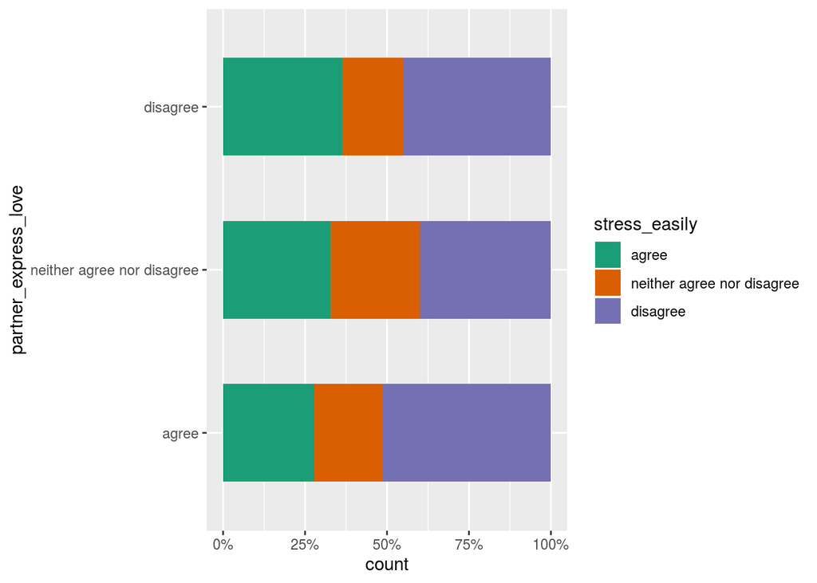

```r
demo %>%

  filter(partner_express_love %in% c("agree","neither agree nor disagree","disagree"),
         stress_easily %in% c("agree","neither agree nor disagree","disagree")) %>%
  droplevels() %>%

  ggplot(aes(x=partner_express_love, fill=stress_easily)) +  ### x=explanatory, fill=response
    geom_bar(position = position_fill(reverse = T), width=.6) +

    scale_fill_brewer(palette="Dark2") +

    scale_y_continuous(labels=percent) +

    coord_flip()
```

## Vigorous Activity by Gender

```r
demo %>%

  filter(vigorous_activity %in% c("yes","no"))  %>%
  droplevels() %>%

  tabyl(gender, vigorous_activity) %>%
    adorn_totals(c("row")) %>%
    adorn_percentages("row") %>%
    adorn_pct_formatting(digits=0) %>%

  kable() %>%
    kable_styling(bootstrap_options = "striped",
                full_width = T,
                position="left") %>%
    add_header_above(c("","vigorous activity"=2))
```

| gender | vigorous activity yes | vigorous activity no |
| --- | --- | --- |
| male | 49% | 51% |
| female | 33% | 67% |
| Total | 40% | 60% |

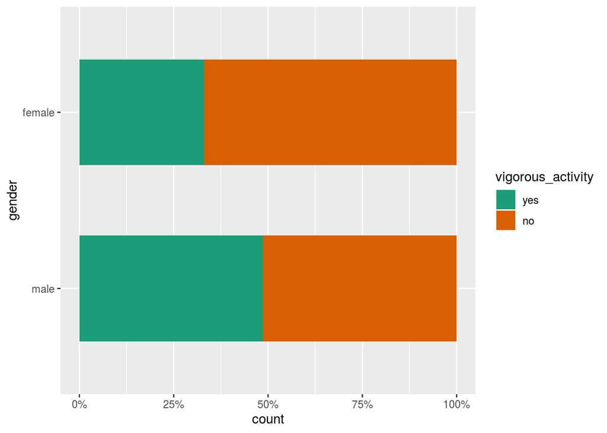

```r
demo %>%

  filter(vigorous_activity %in% c("yes","no"))  %>%
  droplevels() %>%

  ggplot(aes(x=gender, fill=vigorous_activity)) +
    geom_bar(position = position_fill(reverse = TRUE), width=.6) +

    scale_fill_brewer(palette="Dark2") +
    scale_y_continuous(labels=percent) +
    coord_flip()
```

## Gym Use by Gender

### Table

```r
demo %>%

  filter(weekly_gym_use %in% c("no","1-3 times","4 or more times")) %>%
  droplevels() %>%

  tabyl(gender, weekly_gym_use) %>%  ## exp,resp
    adorn_totals(c("row")) %>%
    adorn_percentages("row") %>%
    adorn_pct_formatting(digits=0) %>%
    #adorn_ns() %>%   ## remove if not needed

  kable(booktabs = TRUE) %>%
    kable_styling(bootstrap_options = "striped", full_width = T,
                position="left")   %>%
    add_header_above(c("","weekly gym use"=3))
```

| gender | weekly gym use no | weekly gym use 1-3 times | weekly gym use 4 or more times |
| --- | --- | --- | --- |
| male | 68% | 19% | 13% |
| female | 71% | 19% | 10% |
| Total | 70% | 19% | 11% |

### Bar Graph

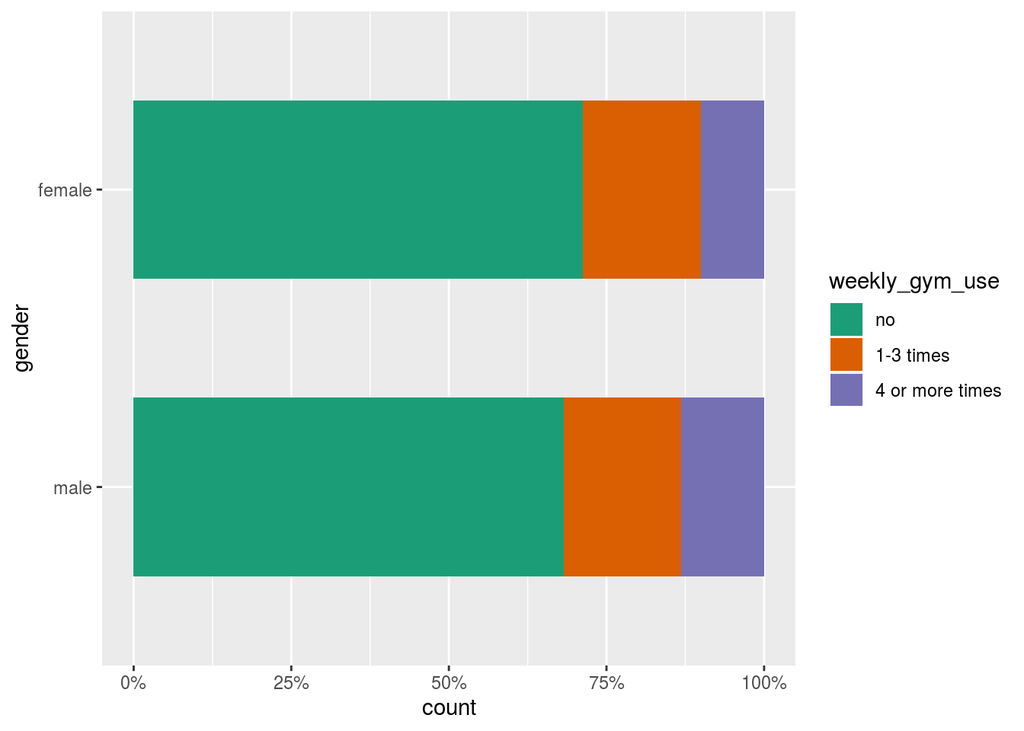

```r
demo %>%

  filter(weekly_gym_use %in% c("no","1-3 times","4 or more times")) %>%
  droplevels() %>%

  ggplot(aes(x=gender, fill=weekly_gym_use)) +  ## x = exp , fill= resp
    geom_bar(position = position_fill(reverse = T), width=.6) +

    scale_fill_brewer(palette="Dark2") +
    scale_y_continuous(labels=percent) +
    coord_flip()
```

# Part Two: Group by a Third Categorical Variable

## Vigorous Activity by Education Level grouped by Gender

```r
demo %>%
  filter(gender =="male") %>%

  filter(vigorous_activity %in% c("yes","no") &
         education %in% c("not hs grad", "hs grad", "post hs", "bachelors", "adv degree")) %>%
  droplevels() %>%

  tabyl(education, vigorous_activity) %>%
    adorn_totals(c("row")) %>%
    adorn_percentages("row") %>%
    adorn_pct_formatting(digits=0) %>%

  kable() %>%
    kable_styling(bootstrap_options = "striped",
                  full_width = T,
                  position="left") %>%
    add_header_above(c("","MALE RESPONSES \n \n vigorous activity"=2))
```

| education | MALE RESPONSES vigorous activity yes | MALE RESPONSES vigorous activity no |
| --- | --- | --- |
| not hs grad | 51% | 49% |
| hs grad | 51% | 49% |
| post hs | 49% | 51% |
| bachelors | 46% | 54% |
| adv degree | 42% | 58% |
| Total | 49% | 51% |

```r
demo %>%

  filter(gender == "female") %>%

  filter(vigorous_activity %in% c("yes","no") &
         education %in% c("not hs grad", "hs grad", "post hs", "bachelors", "adv degree")) %>%
  droplevels() %>%

  tabyl(education, vigorous_activity) %>%
    adorn_totals(c("row")) %>%
    adorn_percentages("row") %>%
    adorn_pct_formatting(digits=0) %>%

  kable(booktabs = TRUE) %>%
    kable_styling(bootstrap_options = "striped",
                  full_width = T,
                  position="left") %>%
    add_header_above(c("","FEMALE RESPONSES \n \n vigorous activity"=2))
```

| education | FEMALE RESPONSES vigorous activity yes | FEMALE RESPONSES vigorous activity no |
| --- | --- | --- |
| not hs grad | 32% | 68% |
| hs grad | 37% | 63% |
| post hs | 33% | 67% |
| bachelors | 32% | 68% |
| adv degree | 33% | 67% |
| Total | 33% | 67% |

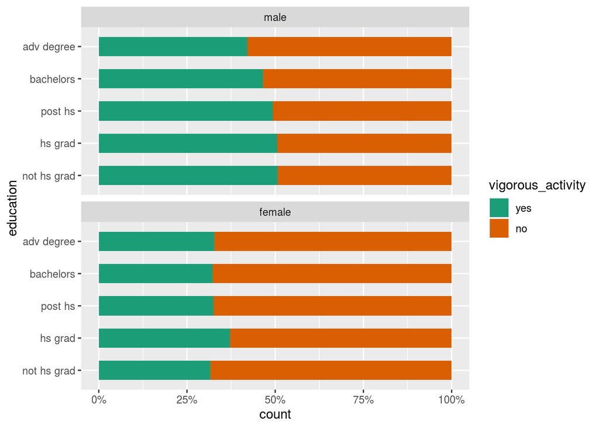

```r
demo %>%

  filter(vigorous_activity %in% c("yes","no") &
         education %in% c("not hs grad", "hs grad", "post hs", "bachelors", "adv degree")) %>%
  droplevels() %>%

  ggplot(aes(x=education, fill=vigorous_activity)) +
    geom_bar(position = position_fill(reverse = TRUE), width=.6) +

    scale_fill_brewer(palette="Dark2") +
    facet_wrap(~gender, ncol=1) +
    scale_y_continuous(labels=percent) +
    coord_flip()
```

## Narrative Summary

When looking at the all `addhealth4`observations, the percent of those who engaging in vigorous activity in the past 24 hours decreases as education level increases, showing a potential association. When comparing vigorous activity with gender, **49% of men** responsed with **yes**, compared to **33% for women**. The relationship between vigorous activiy and education level was different for men and women. The earlier trend of vigorous activity decreasing and education level increases is observed for men, but for women the trends is not observed.

# Part Three: Relationship between numerical and categorical variables

## Analysis of Relationship between Usual Hours Worked Per Week and Educational Level

### Summary Statistics

```r
demo %>%

  filter(hrs_work_week < 121 &
         education %in% c("not hs grad", "hs grad", "post hs", "bachelors", "adv degree")) %>%
  droplevels() %>%

  group_by(education) %>%

  summarize(n = n(),
            min = min(hrs_work_week),
            q1 = quantile(hrs_work_week, probs=0.25),
            median = median(hrs_work_week),
            mean = round(mean(hrs_work_week),1),
            q3 = quantile(hrs_work_week, probs=0.75),
            max = max(hrs_work_week),
            sd = round(sd(hrs_work_week),1)) %>%

  kable() %>%
    kable_styling(bootstrap_options = "striped",
                  full_width = T,
                  position="left")   %>%
    add_header_above(c("hours worked summary statistics "= 9))
```

| hours worked summary statistics education | hours worked summary statistics n | hours worked summary statistics min | hours worked summary statistics q1 | hours worked summary statistics median | hours worked summary statistics mean | hours worked summary statistics q3 | hours worked summary statistics max | hours worked summary statistics sd |
| --- | --- | --- | --- | --- | --- | --- | --- | --- |
| not hs grad | 375 | 10 | 36 | 40 | 40.7 | 45 | 90 | 12.7 |
| hs grad | 805 | 10 | 40 | 40 | 41.1 | 45 | 120 | 11.1 |
| post hs | 2183 | 10 | 37 | 40 | 40.5 | 45 | 120 | 11.6 |
| bachelors | 1246 | 10 | 40 | 40 | 41.9 | 45 | 106 | 10.8 |
| adv degree | 414 | 10 | 40 | 40 | 43.5 | 50 | 80 | 11.2 |

### Visualization (Use the best option)

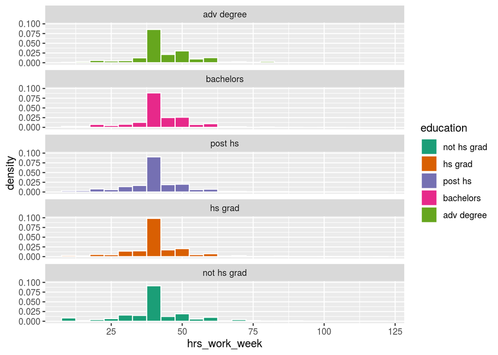

```r
demo %>%

  filter(hrs_work_week < 121 &
         education %in% c("not hs grad", "hs grad", "post hs", "bachelors", "adv degree")) %>%
  droplevels() %>%

  ggplot(aes(hrs_work_week))+

    geom_histogram(aes(y=..density..,
                       fill=education),
                   color="white",
                   binwidth = 5) +

      scale_fill_brewer(palette="Dark2") +

    facet_wrap(~ education,
               ncol=1,
               as.table = FALSE)  ## reverses the order of the levels to match boxplots
```

```r
demo %>%

  filter(hrs_work_week < 121 &
         education %in% c("not hs grad", "hs grad", "post hs", "bachelors", "adv degree")) %>%
  droplevels() %>%

  ggplot(aes(hrs_work_week)) +

    geom_density(aes(fill=education),
                 color="white",
                 adjust=2) +

    scale_fill_brewer(palette="Dark2") +

    facet_wrap(~ education,
               ncol=1,
               as.table = FALSE)  ## reverses the order of the levels to match boxplots
```

[output not shown]

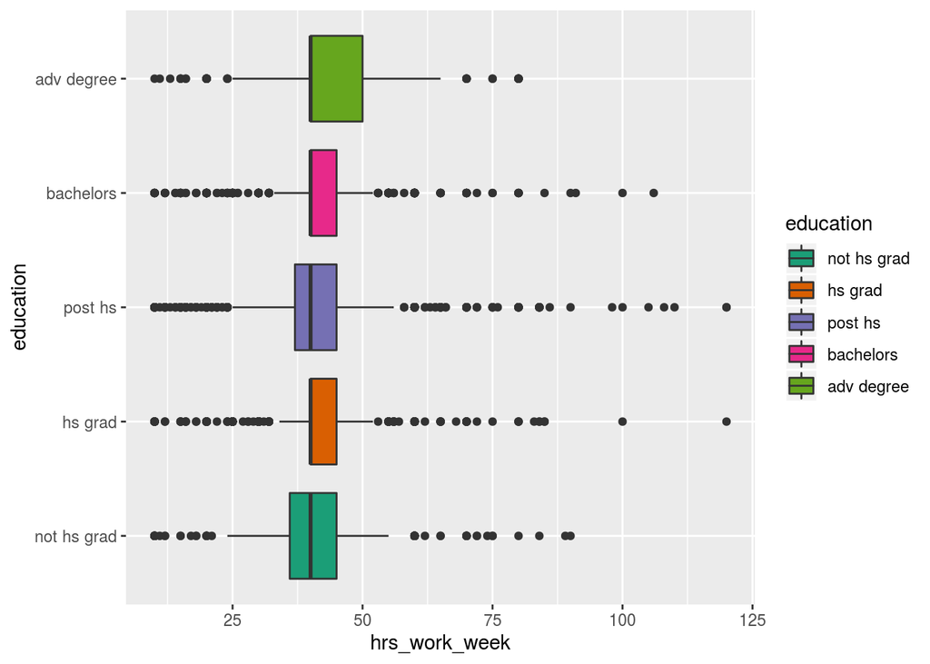

```r
demo %>%

  filter(hrs_work_week < 121 &
         education %in% c("not hs grad", "hs grad", "post hs", "bachelors", "adv degree")) %>%
  droplevels() %>%

  ggplot(aes(y=hrs_work_week, x=education))+

    scale_fill_brewer(palette="Dark2") +

    geom_boxplot(aes(fill=education)) +

    coord_flip()  # might be nice to re-scale axis ( to see middle 50 better)
```

```r
demo %>%

  filter(hrs_work_week < 121 &
         education %in% c("not hs grad", "hs grad", "post hs", "bachelors", "adv degree")) %>%
  droplevels() %>%

  ggplot(aes(y=hrs_work_week, x=education)) +

    geom_violin(aes(fill=education),
                draw_quantiles=c(0.25,0.5,.75),
                adjust=2) +

    scale_fill_brewer(palette="Dark2") +

    coord_flip()
```

[output not shown]

```r
demo %>%

  filter(hrs_work_week < 121 &
         education %in% c("not hs grad", "hs grad", "post hs", "bachelors", "adv degree")) %>%
  droplevels() %>%

  ggplot(aes(x=hrs_work_week, color=education)) +

    geom_density(alpha = 0.1, adjust=2) +

    xlim(10, 80) +

    scale_fill_brewer(palette="Dark2")
```

[output not shown]

### Narrative Summary

When looking at the all `addhealth4`observations, the *percent of those who engaging in vigorous activity in the past 24 hours decreases as education level increases*, showing a potential association. When comparing vigorous activity with gender, **49% of men** responsed with **yes**, compared to **33% for women**, for difference in sample proportions of **16%**. The relationship between vigorous activiy and education level was different for men and women. The earlier trend of vigorous activity decreasing and education level increases is observed for men, but for women the trends is not observed.

# Part Four : Group by a Second Categorical Variable

We will be adding `gender` into the examination of hours work and education level. So, first we will examine the relationship between hours worked and gender, then we will assess how hours worked by education level changes when we group by a second categorical variable of gender.

## Hours worked broken down by Gender

### Numerical Summary

Same commands as earlier for hours/education, except now we will `group_by(gender)`.

```r
demo %>%

  filter(hrs_work_week < 121) %>%
  droplevels() %>%

  group_by(gender) %>%

  summarize(n = n(),
            min = min(hrs_work_week),
            q1 = quantile(hrs_work_week, probs=0.25),
            median = median(hrs_work_week),
            mean = round(mean(hrs_work_week),1),
            q3 = quantile(hrs_work_week, probs=0.75),
            max = max(hrs_work_week),
            sd = round(sd(hrs_work_week),1)) %>%

  kable() %>%
    kable_styling(bootstrap_options = "striped",
                  full_width = T,
                  position="left")   %>%
    add_header_above(c("hours worked summary statistics "= 9))
```

| hours worked summary statistics gender | hours worked summary statistics n | hours worked summary statistics min | hours worked summary statistics q1 | hours worked summary statistics median | hours worked summary statistics mean | hours worked summary statistics q3 | hours worked summary statistics max | hours worked summary statistics sd |
| --- | --- | --- | --- | --- | --- | --- | --- | --- |
| male | 2315 | 10 | 40 | 40 | 44.0 | 50 | 120 | 12.0 |
| female | 2708 | 10 | 35 | 40 | 38.8 | 40 | 120 | 10.3 |

### Visualization - Faceted Histogram

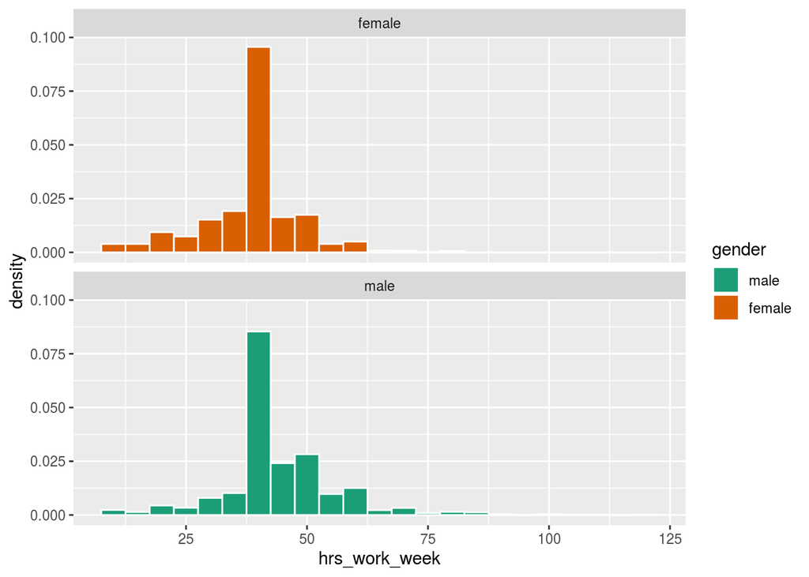

```r
demo %>%

  filter(hrs_work_week < 121) %>%
  droplevels() %>%

  ggplot(aes(hrs_work_week))+

    geom_histogram(aes(y=..density..,
                       fill=gender),
                   color="white",
                   binwidth = 5) +

      scale_fill_brewer(palette="Dark2") +

    facet_wrap(~ gender,
               ncol=1,
               as.table = FALSE)  ## reverses the order of the levels to match boxplots
```

## Examine Hours Worked by Gender grouped Education Level

To create summary statistics grouped by a single variable, the process is similar to what we did earlier for vigorous activity. Just add a filter command for each level of your categorical variable. Here we are grouping by gender so, we are creating two summary tables for each gender.

### Summary Tables

```r
demo %>%

  filter(gender == "male") %>%

  filter(hrs_work_week < 121) %>%
  droplevels() %>%

  group_by(education) %>%

  summarize(n = n(),
            min = min(hrs_work_week),
            q1 = quantile(hrs_work_week, probs=0.25),
            median = median(hrs_work_week),
            mean = round(mean(hrs_work_week),1),
            q3 = quantile(hrs_work_week, probs=0.75),
            max = max(hrs_work_week),
            sd = round(sd(hrs_work_week),1)) %>%

  kable() %>%
    kable_styling(bootstrap_options = "striped",
                  full_width = T,
                  position="left")   %>%
    add_header_above(c("MALE RESPONSES \n \n hours worked summary statistics "= 9))
```

| MALE RESPONSES hours worked summary statistics education | MALE RESPONSES hours worked summary statistics n | MALE RESPONSES hours worked summary statistics min | MALE RESPONSES hours worked summary statistics q1 | MALE RESPONSES hours worked summary statistics median | MALE RESPONSES hours worked summary statistics mean | MALE RESPONSES hours worked summary statistics q3 | MALE RESPONSES hours worked summary statistics max | MALE RESPONSES hours worked summary statistics sd |
| --- | --- | --- | --- | --- | --- | --- | --- | --- |
| not hs grad | 218 | 10 | 40 | 40 | 43.3 | 50.00 | 90 | 13.1 |
| hs grad | 464 | 10 | 40 | 40 | 43.7 | 48.25 | 120 | 11.7 |
| post hs | 981 | 10 | 40 | 40 | 43.9 | 50.00 | 120 | 12.2 |
| bachelors | 512 | 10 | 40 | 40 | 44.5 | 50.00 | 106 | 11.4 |
| adv degree | 140 | 13 | 40 | 42 | 45.0 | 50.00 | 80 | 11.6 |

```r
demo %>%

  filter(gender == "female") %>%

  filter(hrs_work_week < 121) %>%
  droplevels() %>%

  group_by(education) %>%

  summarize(n = n(),
            min = min(hrs_work_week),
            q1 = quantile(hrs_work_week, probs=0.25),
            median = median(hrs_work_week),
            mean = round(mean(hrs_work_week),1),
            q3 = quantile(hrs_work_week, probs=0.75),
            max = max(hrs_work_week),
            sd = round(sd(hrs_work_week),1)) %>%

  kable() %>%
    kable_styling(bootstrap_options = "striped",
                  full_width = T,
                  position="left")   %>%
    add_header_above(c("FEMALE RESPONSES \n \n hours worked summary statistics "= 9))
```

| FEMALE RESPONSES hours worked summary statistics education | FEMALE RESPONSES hours worked summary statistics n | FEMALE RESPONSES hours worked summary statistics min | FEMALE RESPONSES hours worked summary statistics q1 | FEMALE RESPONSES hours worked summary statistics median | FEMALE RESPONSES hours worked summary statistics mean | FEMALE RESPONSES hours worked summary statistics q3 | FEMALE RESPONSES hours worked summary statistics max | FEMALE RESPONSES hours worked summary statistics sd |
| --- | --- | --- | --- | --- | --- | --- | --- | --- |
| not hs grad | 157 | 10 | 32 | 40 | 37.0 | 40 | 72 | 11.1 |
| hs grad | 341 | 10 | 35 | 40 | 37.6 | 40 | 84 | 9.1 |
| post hs | 1202 | 10 | 35 | 40 | 37.7 | 40 | 120 | 10.3 |
| bachelors | 734 | 10 | 40 | 40 | 40.0 | 45 | 91 | 10.0 |
| adv degree | 274 | 10 | 40 | 40 | 42.7 | 50 | 80 | 10.9 |

### Boxplot

In order to include an additional categorical variable add the `aes`thetic `color=gender` to your `ggplot` command. This will split each educational level by gender.

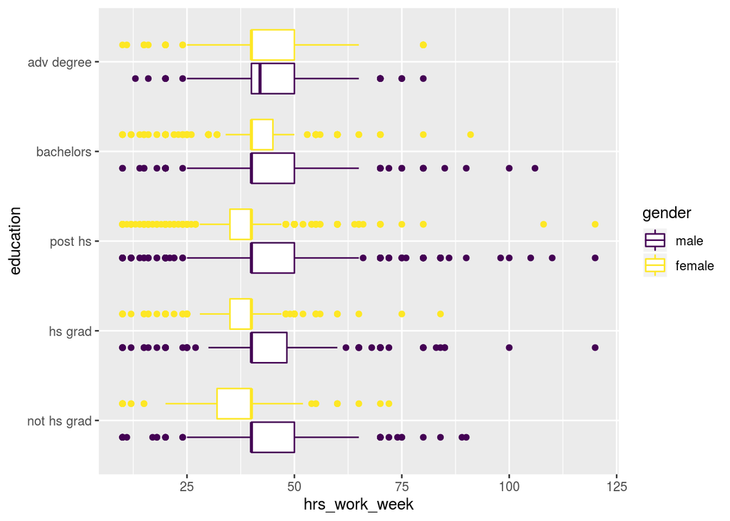

```r
demo %>%

  filter(hrs_work_week < 121) %>%
  droplevels() %>%

  ggplot(aes(y=hrs_work_week, x=education, color=gender))+

    scale_fill_brewer(palette="Dark2") +

    geom_boxplot() +

    coord_flip()  # might be nice to re-scale axis ( to see middle 50 better)
```

### Narrative Summary

When we look closer at usual hours worked by education level, but now grouped by gender - there are some interesting observations. For each level of education the mean hours for women is less than that of men. The difference in the range of middle 50% can be seen in the boxplot above. Only when we examine **adv degree** do we see the middle 50% observations align with eachother across gender.